# example

```python
import os
import pandas as pd
import numpy as np
import pathlib
import copy
import matplotlib.pyplot as plt

from additional_functions import correlation_with_confidence as fcn
```

## Example usage

**The code below demonstrates the use of the proposed method on specific data. Modifications will likely be needed your specific use case.**

### Main functions

- **`mos_distributions = fcn.create_mos_distributions(scene_votes, n_iterations,...)`**

  Inputs:
  - `scene_votes` is **either**:
    - `a dictionary`, where keys are scene/stimuli names/indices and values are lists of measured scores

    ```
    scene_votes = {
        'scene_01': ['vote_01', 'vote_02', 'vote_03'],
        'scene_02': ['vote_01', 'vote_02', 'vote_03']
    }
    ```

    - `a list of lists`, similar to [means, stds, n_votes], where `means`, `stds`, `n_votes` are themselves lists of values

    ```
    scene_votes = [
        ['mean_01', 'mean_02', 'mean_03'],
        ['std_01', 'std_02', 'std_03'],
        ['n_votes_01', 'n_votes_02', 'n_votes_02']
    ]
    ```

  - `n_iterations` is the number of samples/iterations that the resulting distributions should have

  Output:
  - `mos_distributions` is a `numpy.array` of shape `[num_stimuli, n_iterations]`
- **`results = fcn.compute_correlation_distributions(mos_distributions, metric, n_bootstrap, bootstrap_scenes, corr_coeffs)`**

  Inputs:
  - `mos_distributions` is the output of `fcn.create_mos_distributions()`
  - `metric` is a `list` of objective values
  - `n_bootstrap` is the number of bootstraps to use (*should be adjusted based on the required precision and the available computational resources*)
  - `bootstrap_scenes` is a `True`/`False` value that indicates if you want to compute scene bootstrapping or not
  - `corr_coeffs` is a `list` indicating which correlation coefficients to compute (e.g. `['r', 'rho', 'tau']`)

  Output:
  - `results` is a `dictionary` containing lists of results for the specified `corr_coeffs`

```python
root_dir = pathlib.Path('./').absolute()
data_dir = os.path.join(root_dir,'metrics_values')
if not os.path.isdir(data_dir):
    os.makedirs(data_dir)

datasets = {'CID2013': {'path': os.path.join(data_dir, 'CID2013.csv'),
                                  'scene_column': 'Source_ID',
                                  'quality_column': 'Image set specific IQ Score with outlier removal'}}

dataset = 'CID2013'

df = pd.read_csv(datasets[dataset]['path'])
quality_column = datasets[dataset]['quality_column']
scene_column = datasets[dataset]['scene_column']

# Ensure 'Y' column is of string type, then convert to lowercase
df[quality_column] = pd.to_numeric(df[quality_column], errors='coerce')

# Drop rows where 'X' is NaN (which were non-numeric values)
df = df.dropna(subset=[quality_column])

df[scene_column] = df[scene_column].astype(str).str.lower()

# Group by scene names and aggregate votes into lists
scene_votes = df.groupby(scene_column)[quality_column].apply(list).to_dict()
scenes = [x.split('/')[-1] for x in list(scene_votes.keys())]
scene_votes = {str(key.split('/')[-1]).lower(): value for key, value in scene_votes.items()}

# backup copy of the MOS info
scene_votes_original = copy.deepcopy(scene_votes)

csv_dir = os.path.join(root_dir,'metrics_values','CID2013_pyiqa_metrics')

metric_df = pd.read_csv(os.path.join(csv_dir,'CID2013_musiq.csv'))
metric_df_compare = pd.read_csv(os.path.join(csv_dir,'CID2013_dbcnn.csv'))
```

```python
metric_df.head()
```

|  | name | musiq |
| --- | --- | --- |
| 0 | IS_III_C01_D01.jpg | 74.853401 |
| 1 | IS_III_C01_D02.jpg | 58.037872 |
| 2 | IS_III_C01_D03.jpg | 62.406807 |
| 3 | IS_III_C01_D04.jpg | 56.139645 |
| 4 | IS_III_C01_D05.jpg | 20.301790 |

```python
scenes = list(scene_votes_original.keys())[3]
scene_votes = {}

for scene in scenes:
    temp_dict = {key: value for key, value in scene_votes_original.items() if scene in key}
    scene_votes = {**scene_votes, **temp_dict}

# scene_votes is a dictionary, where the key is the name of each scene/stimuli and the value is a list of votes
```

```python
names = metric_df['name'].str.replace('.jpg', '', regex=False).str.lower()

metric = metric_df['musiq'].values

# Create a dictionary mapping names to values
name_to_value = dict(zip(names, metric))

metric = np.array([name_to_value[name] for name in list(scene_votes.keys())])

## Repeat for the other metric

names_compare = metric_df_compare['name'].str.replace('.jpg', '', regex=False).str.lower()
metric_compare = metric_df_compare['dbcnn'].values
name_to_value = dict(zip(names_compare, metric_compare))
metric_compare = np.array([name_to_value[name] for name in list(scene_votes.keys())])
```

### Propagate confidence intervals

The code below shows how to use the prepared scripts, given subjective scores and two objective metrics.

```python
# estimate the distributions of means from raw scores
mos_distributions = fcn.create_mos_distributions(scene_votes=scene_votes, n_iterations=1499)
```

```python
# compute distributions of correlation coefficients
# objective_metric = mos_distributions.mean(axis=1) # using mean subjective scores as the objective metric

objective_metric = metric
correlations = fcn.compute_correlation_distributions(mos_distributions, objective_metric, n_bootstrap=14999, bootstrap_scenes=True, corr_coeffs=['r', 'rho', 'tau'])
```

```python
## the same as above, just for a different objective metric
objective_metric = metric_compare
correlations_compare = fcn.compute_correlation_distributions(mos_distributions, objective_metric, n_bootstrap=14999, bootstrap_scenes=True, corr_coeffs=['r', 'rho', 'tau'])
```

### Plot the results for comparison

Instead of violin plots, we use histograms here, just for simplicity sake (given that we compare only two metrics).

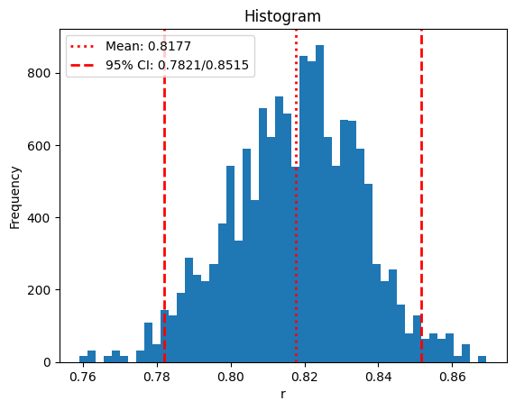

```python
# Plot correlations as histograms
corr_coefficient = 'r'

# compute the confidence interval
mean_value = correlations[corr_coefficient].mean()
perc_low, perc_high = np.abs(np.percentile(correlations[corr_coefficient], [2.5, 97.5]))

plt.hist(correlations[corr_coefficient], bins=50)  # Adjust bins for desired granularity

# add vertical lines for the confidence interval and the mean
plt.axvline(mean_value, color='red', linestyle='dotted', linewidth=2, label=f'Mean: {mean_value:.4f}')
plt.axvline(perc_low, color='red', linestyle='dashed', linewidth=2, label=f'95% CI: {perc_low:.4f}/{perc_high:.4f}')
plt.axvline(perc_high, color='red', linestyle='dashed', linewidth=2)

plt.xlabel(corr_coefficient)
plt.ylabel('Frequency')
plt.title('Histogram')
plt.legend()
plt.show()
```

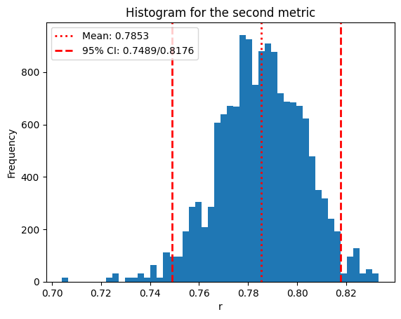

```python
# Plot correlations as histograms for the second metric
corr_coefficient = 'r'

# compute the confidence interval
mean_value = correlations_compare[corr_coefficient].mean()
perc_low, perc_high = np.abs(np.percentile(correlations_compare[corr_coefficient], [2.5, 97.5]))

plt.hist(correlations_compare[corr_coefficient], bins=50)  # Adjust bins for desired granularity

# add vertical lines for the confidence interval and the mean
plt.axvline(mean_value, color='red', linestyle='dotted', linewidth=2, label=f'Mean: {mean_value:.4f}')
plt.axvline(perc_low, color='red', linestyle='dashed', linewidth=2, label=f'95% CI: {perc_low:.4f}/{perc_high:.4f}')
plt.axvline(perc_high, color='red', linestyle='dashed', linewidth=2)

plt.xlabel(corr_coefficient)
plt.ylabel('Frequency')
plt.title('Histogram for the second metric')
plt.legend()
plt.show()
```

### Compute the Cliff's delta results and convert them to probabilities

The conversion to probabilities is done to improve the interpretation of results

```python
# Compute Cliff's delta between the results of the two metrics

for key in list(correlations.keys()):
    cliffs_delta = fcn.cliffs_delta(correlations[key], correlations_compare[key])
    win_probability = ((cliffs_delta + 1) / 2)*100
    print(f'Win probability for {key} = {win_probability}')
```

```
Win probability for r = 90.52476778892844
Win probability for rho = 62.235842280144716
Win probability for tau = 76.91285603897028
```

## Same as above, just without scene bootstrapping

```python
# WITHOUT scene bootstrapping
# compute distributions of correlation coefficients
# objective_metric = mos_distributions.mean(axis=1) # using mean subjective scores as the objective metric

objective_metric = metric # using a predifined objective metric
correlations = fcn.compute_correlation_distributions(mos_distributions, objective_metric, n_bootstrap=14999, bootstrap_scenes=False, corr_coeffs=['r', 'rho', 'tau'])
```

```python
# same as above, just for the second metric

objective_metric = metric_compare # using a predifined objective metric
correlations_compare = fcn.compute_correlation_distributions(mos_distributions, objective_metric, n_bootstrap=14999, bootstrap_scenes=False, corr_coeffs=['r', 'rho', 'tau'])
```

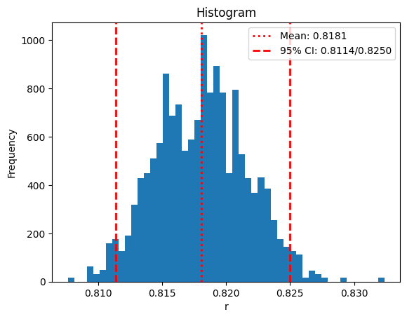

```python
# compute the confidence interval
mean_value = correlations[corr_coefficient].mean()
perc_low, perc_high = np.abs(np.percentile(correlations[corr_coefficient], [2.5, 97.5]))

plt.hist(correlations[corr_coefficient], bins=50)  # Adjust bins for desired granularity

# add vertical lines for the confidence interval and the mean
plt.axvline(mean_value, color='red', linestyle='dotted', linewidth=2, label=f'Mean: {mean_value:.4f}')
plt.axvline(perc_low, color='red', linestyle='dashed', linewidth=2, label=f'95% CI: {perc_low:.4f}/{perc_high:.4f}')
plt.axvline(perc_high, color='red', linestyle='dashed', linewidth=2)

plt.xlabel(corr_coefficient)
plt.ylabel('Frequency')
plt.title('Histogram')
plt.legend()
plt.show()
```

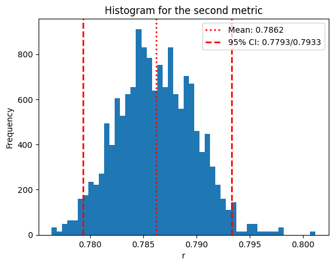

```python
# compute the confidence interval
mean_value = correlations_compare[corr_coefficient].mean()
perc_low, perc_high = np.abs(np.percentile(correlations_compare[corr_coefficient], [2.5, 97.5]))

plt.hist(correlations_compare[corr_coefficient], bins=50)  # Adjust bins for desired granularity

# add vertical lines for the confidence interval and the mean
plt.axvline(mean_value, color='red', linestyle='dotted', linewidth=2, label=f'Mean: {mean_value:.4f}')
plt.axvline(perc_low, color='red', linestyle='dashed', linewidth=2, label=f'95% CI: {perc_low:.4f}/{perc_high:.4f}')
plt.axvline(perc_high, color='red', linestyle='dashed', linewidth=2)

plt.xlabel(corr_coefficient)
plt.ylabel('Frequency')
plt.title('Histogram for the second metric')
plt.legend()
plt.show()
```

```python
# Compute Cliff's delta between the results of the two metrics

for key in list(correlations.keys()):
    cliffs_delta = fcn.cliffs_delta(correlations[key], correlations_compare[key])
    win_probability = ((cliffs_delta + 1) / 2)*100
    print(f'Win probability for {key} = {win_probability}')
```

```
Win probability for r = 100.0
Win probability for rho = 90.88523807225302
Win probability for tau = 99.8897204076556
```

## The same using summary statistics

```python
means = []
stds = []
# compute summary statistics from raw scores
for key in list(scene_votes.keys()):
    means.append(np.mean(scene_votes[key]))
    stds.append(np.std(scene_votes[key]))
```

```python
# estimate the distributions of means from summary statistics

# need to supply the number of casted votes to model
n_votes = len(scene_votes['is_i_c01_d01'])
# n_votes = 60

mos_distributions_mean_bootstrap = fcn.create_mos_distributions(scene_votes=[means, stds, n_votes], n_iterations=1499)
```

```python
# compute distributions of correlation coefficients
# objective_metric = mos_distributions_mean_bootstrap.mean(axis=1) # using mean subjective scores as the objective metric

objective_metric = metric # using a predifined objective metric
correlations = fcn.compute_correlation_distributions(mos_distributions_mean_bootstrap, objective_metric, n_bootstrap=14999, bootstrap_scenes=True, corr_coeffs=['r', 'rho', 'tau'])
```

```python
# same as above, just for the second objective metric

objective_metric = metric_compare # using a predifined objective metric
correlations_compare = fcn.compute_correlation_distributions(mos_distributions_mean_bootstrap, objective_metric, n_bootstrap=14999, bootstrap_scenes=True, corr_coeffs=['r', 'rho', 'tau'])
```

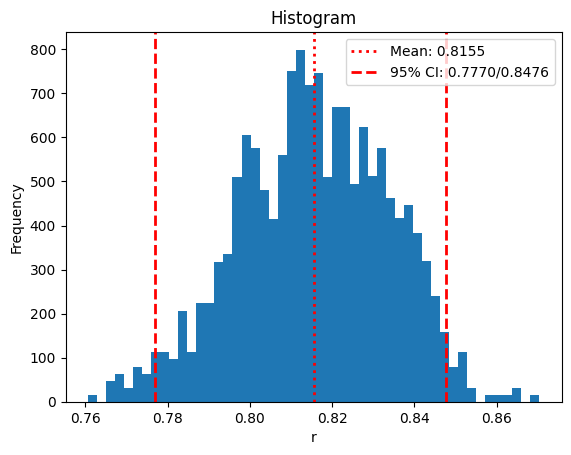

```python
# Plot correlations as histograms
corr_coefficient = 'r'

# compute the confidence interval
mean_value = correlations[corr_coefficient].mean()
perc_low, perc_high = np.abs(np.percentile(correlations[corr_coefficient], [2.5, 97.5]))

plt.hist(correlations[corr_coefficient], bins=50)  # Adjust bins for desired granularity

# add vertical lines for the confidence interval and the mean
plt.axvline(mean_value, color='red', linestyle='dotted', linewidth=2, label=f'Mean: {mean_value:.4f}')
plt.axvline(perc_low, color='red', linestyle='dashed', linewidth=2, label=f'95% CI: {perc_low:.4f}/{perc_high:.4f}')
plt.axvline(perc_high, color='red', linestyle='dashed', linewidth=2)

plt.xlabel(corr_coefficient)
plt.ylabel('Frequency')
plt.title('Histogram')
plt.legend()
plt.show()
```

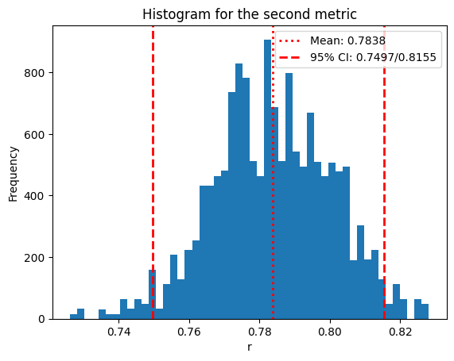

```python
# Plot correlations as histograms
corr_coefficient = 'r'

# compute the confidence interval
mean_value = correlations_compare[corr_coefficient].mean()
perc_low, perc_high = np.abs(np.percentile(correlations_compare[corr_coefficient], [2.5, 97.5]))

plt.hist(correlations_compare[corr_coefficient], bins=50)  # Adjust bins for desired granularity

# add vertical lines for the confidence interval and the mean
plt.axvline(mean_value, color='red', linestyle='dotted', linewidth=2, label=f'Mean: {mean_value:.4f}')
plt.axvline(perc_low, color='red', linestyle='dashed', linewidth=2, label=f'95% CI: {perc_low:.4f}/{perc_high:.4f}')
plt.axvline(perc_high, color='red', linestyle='dashed', linewidth=2)

plt.xlabel(corr_coefficient)
plt.ylabel('Frequency')
plt.title('Histogram for the second metric')
plt.legend()
plt.show()
```

```python
# Compute Cliff's delta between the results of the two metrics

for key in list(correlations.keys()):
    cliffs_delta = fcn.cliffs_delta(correlations[key], correlations_compare[key])
    win_probability = ((cliffs_delta + 1) / 2)*100
    print(f'Win probability for {key} = {win_probability}')
```

```
Win probability for r = 89.70262217316699
Win probability for rho = 62.207375818076294
Win probability for tau = 75.99431445973102
```

```python
# WITHOUT scene bootstrapping
# compute distributions of correlation coefficients
# objective_metric = mos_distributions_mean_bootstrap.mean(axis=1) # using mean subjective scores as the objective metric

objective_metric = metric # using a predifined objective metric
correlations = fcn.compute_correlation_distributions(mos_distributions_mean_bootstrap, objective_metric, n_bootstrap=14999, bootstrap_scenes=False, corr_coeffs=['r', 'rho', 'tau'])
```

```python
# same as above, just for the second metric

objective_metric = metric_compare # using a predifined objective metric
correlations_compare = fcn.compute_correlation_distributions(mos_distributions_mean_bootstrap, objective_metric, n_bootstrap=14999, bootstrap_scenes=False, corr_coeffs=['r', 'rho', 'tau'])
```

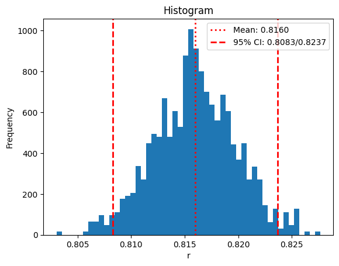

```python
# compute the confidence interval
mean_value = correlations[corr_coefficient].mean()
perc_low, perc_high = np.abs(np.percentile(correlations[corr_coefficient], [2.5, 97.5]))

plt.hist(correlations[corr_coefficient], bins=50)  # Adjust bins for desired granularity

# add vertical lines for the confidence interval and the mean
plt.axvline(mean_value, color='red', linestyle='dotted', linewidth=2, label=f'Mean: {mean_value:.4f}')
plt.axvline(perc_low, color='red', linestyle='dashed', linewidth=2, label=f'95% CI: {perc_low:.4f}/{perc_high:.4f}')
plt.axvline(perc_high, color='red', linestyle='dashed', linewidth=2)

plt.xlabel(corr_coefficient)
plt.ylabel('Frequency')
plt.title('Histogram')
plt.legend()
plt.show()
```

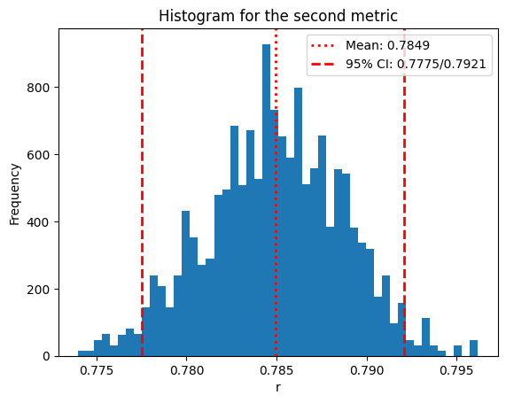

```python
# compute the confidence interval
mean_value = correlations_compare[corr_coefficient].mean()
perc_low, perc_high = np.abs(np.percentile(correlations_compare[corr_coefficient], [2.5, 97.5]))

plt.hist(correlations_compare[corr_coefficient], bins=50)  # Adjust bins for desired granularity

# add vertical lines for the confidence interval and the mean
plt.axvline(mean_value, color='red', linestyle='dotted', linewidth=2, label=f'Mean: {mean_value:.4f}')
plt.axvline(perc_low, color='red', linestyle='dashed', linewidth=2, label=f'95% CI: {perc_low:.4f}/{perc_high:.4f}')
plt.axvline(perc_high, color='red', linestyle='dashed', linewidth=2)

plt.xlabel(corr_coefficient)
plt.ylabel('Frequency')
plt.title('Histogram for the second metric')
plt.legend()
plt.show()
```

```python
# Compute Cliff's delta between the results of the two metrics

for key in list(correlations.keys()):
    cliffs_delta = fcn.cliffs_delta(correlations[key], correlations_compare[key])
    win_probability = ((cliffs_delta + 1) / 2)*100
    print(f'Win probability for {key} = {win_probability}')
```

```
Win probability for r = 100.0
Win probability for rho = 90.59842649865126
Win probability for tau = 99.93040138716096
```

## Compare the MOS distributions

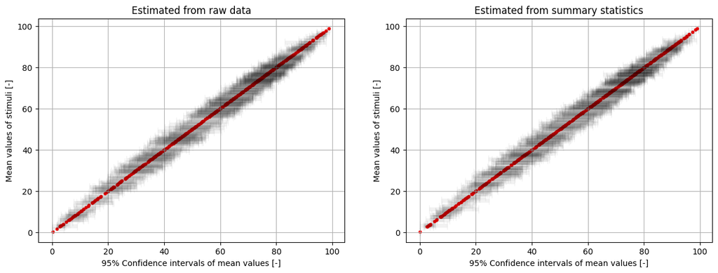

```python
import matplotlib.pyplot as plt

fig, axs = plt.subplots(1,2,figsize=(15, 5))
titles = ['Estimated from raw data', 'Estimated from summary statistics']

for idx, data in enumerate([mos_distributions, mos_distributions_mean_bootstrap]):

    data_x = data
    data_y = data.mean(axis=1)

    # Compute the mean (or median) of the bootstrap samples for each point
    mean_x = np.mean(data_x, axis=1)

    # Compute the percentiles for the confidence intervals (e.g., 2.5th and 97.5th for 95% CI)
    ci_lower_x = np.percentile(data_x, 2.5, axis=1)
    ci_upper_x = np.percentile(data_x, 97.5, axis=1)

    # Compute the error bars as the distance from the mean to the confidence bounds
    error_x = [mean_x - ci_lower_x, ci_upper_x - mean_x]
    error_x[0] = [0 if x < 0 else x for x in error_x[0]]
    error_x[1] = [0 if x < 0 else x for x in error_x[1]]
    # error_y = [mean_y - ci_lower_y, ci_upper_y - mean_y]

    # Create the scatter plot with percentile-based error bars
    axs[idx].errorbar(mean_x, data_y, xerr=error_x, fmt=' ', color='white', ecolor='black', elinewidth=5, capsize=5, label='Data points', alpha=0.05)
    axs[idx].scatter(mean_x, data_y, color='red', marker='o', s=10, alpha=1)

    axs[idx].set_xlabel('95% Confidence intervals of mean values [-]')
    axs[idx].set_ylabel('Mean values of stimuli [-]')
    axs[idx].set_title(titles[idx])
    axs[idx].grid(True)

    # Customize the plot

# plt.legend()
plt.show()
```

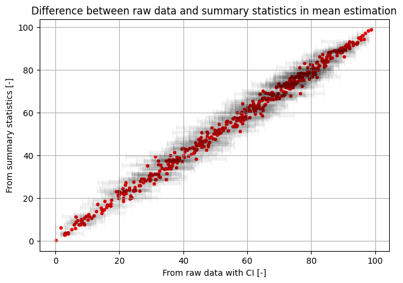

```python
import numpy as np
import matplotlib.pyplot as plt

data_x = mos_distributions
data_y = mos_distributions_mean_bootstrap.mean(axis=1)

# Compute the mean (or median) of the bootstrap samples for each point
mean_x = np.mean(data_x, axis=1)
# mean_y = np.mean(data_y)

# Compute the percentiles for the confidence intervals (e.g., 2.5th and 97.5th for 95% CI)
ci_lower_x = np.percentile(data_x, 2.5, axis=1)
ci_upper_x = np.percentile(data_x, 97.5, axis=1)

# ci_lower_y = np.percentile(data_y, 2.5)
# ci_upper_y = np.percentile(data_y, 97.5)

# Compute the error bars as the distance from the mean to the confidence bounds
error_x = [mean_x - ci_lower_x, ci_upper_x - mean_x]
error_x[0] = [0 if x < 0 else x for x in error_x[0]]
error_x[1] = [0 if x < 0 else x for x in error_x[1]]
# error_y = [mean_y - ci_lower_y, ci_upper_y - mean_y]

# Create the scatter plot with percentile-based error bars
fig = plt.figure(figsize=(7.5, 5))
plt.errorbar(mean_x, data_y, xerr=error_x, fmt=' ', color='white', ecolor='black', elinewidth=4, capsize=5, label='Data points', alpha=0.05)
plt.scatter(mean_x, data_y, color='red', marker='o', s=10, alpha=1)

# Customize the plot
plt.xlabel('From raw data with CI [-]')
plt.ylabel('From summary statistics [-]')
# plt.xlim([0,1.6])
plt.title('Difference between raw data and summary statistics in mean estimation')
plt.grid(True)
# plt.legend()
plt.show()
```

The the estimated distributions of means from raw data and from summary statistics are not perfectly alligned; however, the difference is relatively small (see the values below).

```python
import scipy.stats as stats

print(f'Pearson\'s r: {stats.pearsonr(mos_distributions_mean_bootstrap.mean(axis=1), mos_distributions.mean(axis=1))[0]:.4f}')
print(f'Spearmans\'s rho: {stats.spearmanr(mos_distributions_mean_bootstrap.mean(axis=1), mos_distributions.mean(axis=1))[0]:.4f}')

# scale is 0-100
normalized_rmse = np.sqrt(((mos_distributions.mean(axis=1) - mos_distributions_mean_bootstrap.mean(axis=1)) ** 2).mean())/100
print(f'RMSE: {normalized_rmse:.4f}')
```

```
Pearson's r: 0.9967
Spearmans's rho: 0.9959
RMSE: 0.0205
```

## Example on the Koniq dataset

```python
root_dir = pathlib.Path('./').absolute()
data_dir = os.path.join(root_dir,'metrics_values')
if not os.path.isdir(data_dir):
    os.makedirs(data_dir)

output = os.path.join(data_dir,'koniq10k.csv')
if not os.path.isfile(output):
    !wget --no-check-certificate 'https://www.dropbox.com/s/6uffdvqb257d2q2/koniq%2B%2Bdatabase.csv?dl=1' -O {output}

datasets = {'koniq10k': {'path': os.path.join(data_dir, 'koniq10k.csv'),
                                  'scene_column': 'filename',
                                  'quality_column': 'qmos',
                                  'sd_column': 'sd'}}

dataset = 'koniq10k'

df = pd.read_csv(datasets[dataset]['path'])
quality_column = datasets[dataset]['quality_column']
scene_column = datasets[dataset]['scene_column']
sd_column = datasets[dataset]['sd_column']

# Ensure 'Y' column is of string type, then convert to lowercase
df[quality_column] = pd.to_numeric(df[quality_column], errors='coerce')

# Drop rows where 'X' is NaN (which were non-numeric values)
df = df.dropna(subset=[quality_column])

# Ensure 'Y' column is of string type, then convert to lowercase
df[sd_column] = pd.to_numeric(df[sd_column], errors='coerce')

# Drop rows where 'X' is NaN (which were non-numeric values)
df = df.dropna(subset=[sd_column])

df[scene_column] = df[scene_column].astype(str).str.lower()

df['mos'] = df[quality_column]
df['std'] = df[sd_column]
df['name'] = df['filename']

df = df.drop([quality_column, sd_column, 'filename'], axis=1)
df = df.sort_values(by=['name'], ascending=True).reset_index(drop=True)
df.head()
```

|  | votes | artifacts | blur | contrast | colors | other | degraded.amount | mos | std | name |
| --- | --- | --- | --- | --- | --- | --- | --- | --- | --- | --- |
| 0 | 62 | 0.016129 | 0.000000 | 0.016129 | 0.016129 | 0.0 | 0.009677 | 4.645161 | 0.515236 | 10004473376.jpg |
| 1 | 59 | 0.118644 | 0.000000 | 0.050847 | 0.033898 | 0.0 | 0.040678 | 3.983051 | 0.656310 | 10007357496.jpg |
| 2 | 58 | 0.068966 | 0.000000 | 0.017241 | 0.000000 | 0.0 | 0.017241 | 4.603448 | 0.560064 | 10007903636.jpg |
| 3 | 55 | 0.072727 | 0.018182 | 0.072727 | 0.072727 | 0.0 | 0.047273 | 4.218182 | 0.658025 | 10009096245.jpg |
| 4 | 62 | 0.096774 | 0.064516 | 0.048387 | 0.048387 | 0.0 | 0.051613 | 4.129032 | 0.712508 | 100117038.jpg |

If we have only summary statistics, we can supply them directly to the create_mos_distributions function.

```python
lower = np.floor(df['mos'].min())
upper = np.ceil(df['mos'].max())
mos_distributions_mean_bootstrap = fcn.create_mos_distributions(scene_votes=[df['mos'].values, df['std'].values, df['votes'].values], n_iterations=1499, lower=lower, upper=upper, resample=False)
```

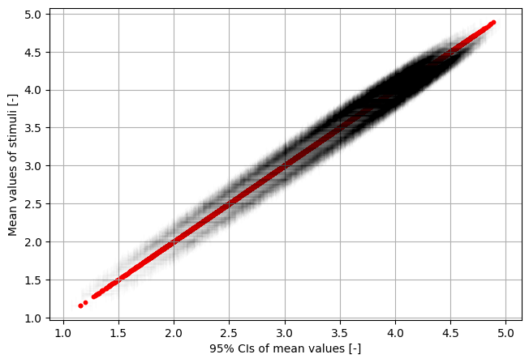

```python
import numpy as np
import matplotlib.pyplot as plt

data_x = mos_distributions_mean_bootstrap
data_y = mos_distributions_mean_bootstrap.mean(axis=1)

# Compute the mean (or median) of the bootstrap samples for each point
mean_x = np.mean(data_x, axis=1)
# mean_y = np.mean(data_y)

# Compute the percentiles for the confidence intervals (e.g., 2.5th and 97.5th for 95% CI)
ci_lower_x = np.percentile(data_x, 2.5, axis=1)
ci_upper_x = np.percentile(data_x, 97.5, axis=1)

# ci_lower_y = np.percentile(data_y, 2.5)
# ci_upper_y = np.percentile(data_y, 97.5)

# Compute the error bars as the distance from the mean to the confidence bounds
error_x = [mean_x - ci_lower_x, ci_upper_x - mean_x]
error_x[0] = [0 if x < 0 else x for x in error_x[0]]
error_x[1] = [0 if x < 0 else x for x in error_x[1]]
# error_y = [mean_y - ci_lower_y, ci_upper_y - mean_y]

# Create the scatter plot with percentile-based error bars
fig = plt.figure(figsize=(7.5, 5))
plt.errorbar(mean_x, data_y, xerr=error_x, fmt=' ', color='white', ecolor='black', elinewidth=1, capsize=5, label='Data points', alpha=0.01)
plt.scatter(mean_x, data_y, color='red', marker='o', s=10, alpha=1)

# Customize the plot
plt.xlabel('95% CIs of mean values [-]')
plt.ylabel('Mean values of stimuli [-]')
# plt.xlim([0,1.6])
# plt.title('Scatter plot with bootstrap confidence intervals')
plt.grid(True)
# plt.legend()
plt.show()
```

```python
lower = np.floor(df['mos'].min())
upper = np.ceil(df['mos'].max())
mos_distributions_mean_bootstrap_resample = fcn.create_mos_distributions(scene_votes=[df['mos'].values, df['std'].values, df['votes'].values], n_iterations=1499, lower=lower, upper=upper, resample=True)
```

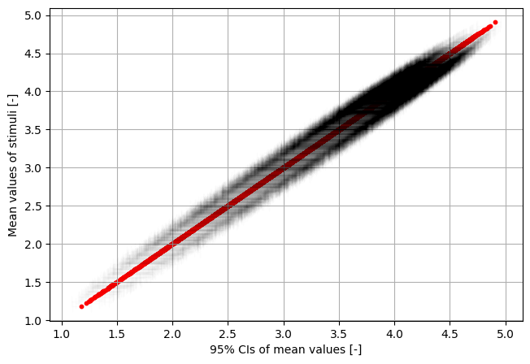

```python
import numpy as np
import matplotlib.pyplot as plt

data_x = mos_distributions_mean_bootstrap_resample
data_y = mos_distributions_mean_bootstrap_resample.mean(axis=1)

# Compute the mean (or median) of the bootstrap samples for each point
mean_x = np.mean(data_x, axis=1)
# mean_y = np.mean(data_y)

# Compute the percentiles for the confidence intervals (e.g., 2.5th and 97.5th for 95% CI)
ci_lower_x = np.percentile(data_x, 2.5, axis=1)
ci_upper_x = np.percentile(data_x, 97.5, axis=1)

# ci_lower_y = np.percentile(data_y, 2.5)
# ci_upper_y = np.percentile(data_y, 97.5)

# Compute the error bars as the distance from the mean to the confidence bounds
error_x = [mean_x - ci_lower_x, ci_upper_x - mean_x]
error_x[0] = [0 if x < 0 else x for x in error_x[0]]
error_x[1] = [0 if x < 0 else x for x in error_x[1]]
# error_y = [mean_y - ci_lower_y, ci_upper_y - mean_y]

# Create the scatter plot with percentile-based error bars
fig = plt.figure(figsize=(7.5, 5))
plt.errorbar(mean_x, data_y, xerr=error_x, fmt=' ', color='white', ecolor='black', elinewidth=1, capsize=5, label='Data points', alpha=0.01)
plt.scatter(mean_x, data_y, color='red', marker='o', s=10, alpha=1)

# Customize the plot
plt.xlabel('95% CIs of mean values [-]')
plt.ylabel('Mean values of stimuli [-]')
# plt.xlim([0,1.6])
# plt.title('Scatter plot with bootstrap confidence intervals')
plt.grid(True)
# plt.legend()
plt.show()
```

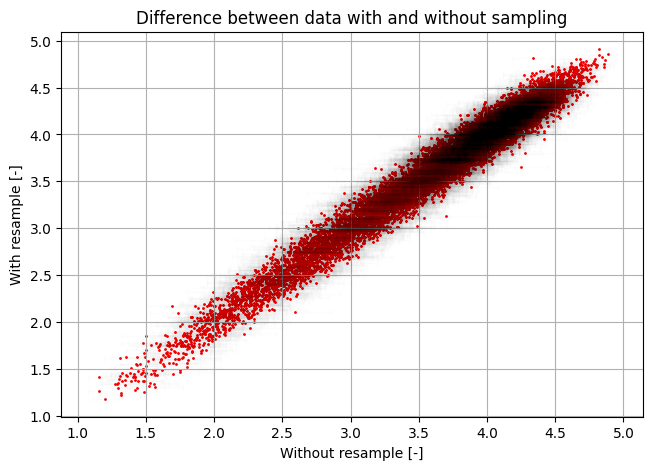

```python
import numpy as np
import matplotlib.pyplot as plt

data_x = mos_distributions_mean_bootstrap
data_y = mos_distributions_mean_bootstrap_resample.mean(axis=1)

# Compute the mean (or median) of the bootstrap samples for each point
mean_x = np.mean(data_x, axis=1)
# mean_y = np.mean(data_y)

# Compute the percentiles for the confidence intervals (e.g., 2.5th and 97.5th for 95% CI)
ci_lower_x = np.percentile(data_x, 2.5, axis=1)
ci_upper_x = np.percentile(data_x, 97.5, axis=1)

# ci_lower_y = np.percentile(data_y, 2.5)
# ci_upper_y = np.percentile(data_y, 97.5)

# Compute the error bars as the distance from the mean to the confidence bounds
error_x = [mean_x - ci_lower_x, ci_upper_x - mean_x]
error_x[0] = [0 if x < 0 else x for x in error_x[0]]
error_x[1] = [0 if x < 0 else x for x in error_x[1]]
# error_y = [mean_y - ci_lower_y, ci_upper_y - mean_y]

# Create the scatter plot with percentile-based error bars
fig = plt.figure(figsize=(7.5, 5))
plt.errorbar(mean_x, data_y, xerr=error_x, fmt=' ', color='white', ecolor='black', elinewidth=1, capsize=2, label='Data points', alpha=0.01)
plt.scatter(mean_x, data_y, color='red', marker='o', s=1, alpha=1)

# Customize the plot
plt.xlabel('Without resample [-]')
plt.ylabel('With resample [-]')
# plt.xlim([0,1.6])
plt.title('Difference between data with and without sampling')
plt.grid(True)
# plt.legend()
plt.show()
```

```python
import scipy.stats as stats

print(f'Pearson\'s r: {stats.pearsonr(mos_distributions_mean_bootstrap.mean(axis=1), mos_distributions_mean_bootstrap_resample.mean(axis=1))[0]:.4f}')
print(f'Spearmans\'s rho: {stats.spearmanr(mos_distributions_mean_bootstrap.mean(axis=1), mos_distributions_mean_bootstrap_resample.mean(axis=1))[0]:.4f}')

# scale is 1-5
normalized_rmse = np.sqrt(((mos_distributions_mean_bootstrap_resample.mean(axis=1) - mos_distributions_mean_bootstrap.mean(axis=1)) ** 2).mean())/4
print(f'NRMSE: {normalized_rmse:.4f}')
```

```
Pearson's r: 0.9838
Spearmans's rho: 0.9764
NRMSE: 0.0314
```